# ManyBabies Habituation Project

```r
# HABITUATION SLOPE ANALYSIS

# Do infants sitting alone habituate FASTER (steeper negative slope)?
# A more negative trend for Sitting Alone = more efficient processing
emtrends(model_random_intercepts,
         pairwise ~ caregiver_seat | method,
         var = "trial_sc")
```

```
$emtrends
method = eyetracking:
 caregiver_seat trial_sc.trend     SE  df asymp.LCL asymp.UCL
 Caregiver Lap         -0.1617 0.0138 Inf   -0.1886   -0.1347
 Sitting Alone         -0.1872 0.0233 Inf   -0.2329   -0.1415

method = hpp:
 caregiver_seat trial_sc.trend     SE  df asymp.LCL asymp.UCL
 Caregiver Lap         -0.1213 0.0135 Inf   -0.1478   -0.0948
 Sitting Alone         -0.1193 0.0957 Inf   -0.3069    0.0682

method = singlescreen:
 caregiver_seat trial_sc.trend     SE  df asymp.LCL asymp.UCL
 Caregiver Lap         -0.0743 0.0117 Inf   -0.0972   -0.0515
 Sitting Alone         -0.1847 0.0511 Inf   -0.2849   -0.0846

Results are averaged over the levels of: trial_type
Degrees-of-freedom method: asymptotic
Confidence level used: 0.95

$contrasts
method = eyetracking:
 contrast                      estimate     SE  df z.ratio p.value
 Caregiver Lap - Sitting Alone  0.02553 0.0262 Inf   0.976  0.3290

method = hpp:
 contrast                      estimate     SE  df z.ratio p.value
 Caregiver Lap - Sitting Alone -0.00195 0.0964 Inf  -0.020  0.9838

method = singlescreen:
 contrast                      estimate     SE  df z.ratio p.value
 Caregiver Lap - Sitting Alone  0.11037 0.0520 Inf   2.121  0.0339

Results are averaged over the levels of: trial_type
Degrees-of-freedom method: asymptotic
```

```r
# EYETRACKING DEEP-DIVE MODEL

eye_data <- subset(data_rq3, method == "eyetracking")

eye_model <- lmer(
  log_lt ~ ns(trial_sc, 4) * caregiver_seat * age_sc +
    trial_type +
    (1 | project_id) +
    #(1 | stimulus_id) +
    (1 | lab_id) +
    (1 | unique_subject_identifier),
  data = eye_data,
  control = lmerControl(optimizer = "bobyqa")
)

# NB: To ensure model stability and convergence within the eyetracking subsample, the random effect of stimulus_id was removed here. This was justified by the omnibus model results, which showed that stimulus-level variance was negligible and that stimulus-category differences were already sufficiently captured by the trial_type fixed effect.

#summary(eye_model)

tab_model(eye_model, show.std = TRUE,
          title = "Eyetracking Model: Seating × Age × Habituation")
```

Eyetracking Model: Seating × Age × Habituation

|  | log_lt |  |  |  |  |  |
| --- | --- | --- | --- | --- | --- | --- |
| Predictors | Estimates | std. Beta | CI | standardized CI | p | std. p |
| (Intercept) | 1.73 | 0.22 | 1.31 – 2.15 | -0.32 – 0.76 | **<0.001** | 0.434 |
| trial sc [1st degree] | -0.31 | -0.40 | -0.35 – -0.26 | -0.46 – -0.34 | **<0.001** | **<0.001** |
| trial sc [2nd degree] | -0.46 | -0.60 | -0.51 – -0.42 | -0.66 – -0.54 | **<0.001** | **<0.001** |
| trial sc [3rd degree] | -0.83 | -1.07 | -0.91 – -0.75 | -1.17 – -0.97 | **<0.001** | **<0.001** |
| trial sc [4th degree] | -0.55 | -0.71 | -0.60 – -0.50 | -0.77 – -0.64 | **<0.001** | **<0.001** |
| caregiver seat [Sitting Alone] | 0.28 | 0.36 | 0.16 – 0.40 | 0.21 – 0.51 | **<0.001** | **<0.001** |
| age sc | 0.06 | 0.09 | 0.02 – 0.11 | 0.03 – 0.15 | **0.006** | **0.006** |
| trial type [consistent] | 0.11 | 0.14 | -0.50 – 0.72 | -0.64 – 0.92 | 0.725 | 0.725 |
| trial type [IDS] | 0.08 | 0.11 | 0.06 – 0.10 | 0.08 – 0.13 | **<0.001** | **<0.001** |
| trial type [inconsistent] | 0.11 | 0.14 | -0.50 – 0.72 | -0.64 – 0.92 | 0.732 | 0.732 |
| trial type [nonsocial] | 0.57 | 0.73 | -0.09 – 1.24 | -0.11 – 1.58 | 0.090 | 0.090 |
| trial type [social] | 0.92 | 1.17 | 0.26 – 1.58 | 0.33 – 2.02 | **0.006** | **0.006** |
| trial sc [1st degree] × caregiver seat [Sitting Alone] | -0.00 | -0.01 | -0.09 – 0.09 | -0.12 – 0.11 | 0.997 | 0.918 |
| trial sc [2nd degree] × caregiver seat [Sitting Alone] | -0.14 | -0.18 | -0.23 – -0.05 | -0.30 – -0.07 | **0.003** | **0.002** |
| trial sc [3rd degree] × caregiver seat [Sitting Alone] | -0.22 | -0.30 | -0.38 – -0.05 | -0.50 – -0.09 | **0.009** | **0.005** |
| trial sc [4th degree] × caregiver seat [Sitting Alone] | -0.01 | -0.01 | -0.10 – 0.08 | -0.12 – 0.10 | 0.840 | 0.816 |
| trial sc [1st degree] × age sc | -0.04 | -0.06 | -0.09 – 0.00 | -0.12 – 0.01 | 0.078 | 0.078 |
| trial sc [2nd degree] × age sc | -0.04 | -0.06 | -0.08 – 0.00 | -0.12 – 0.01 | 0.078 | 0.078 |
| trial sc [3rd degree] × age sc | -0.10 | -0.14 | -0.18 – -0.02 | -0.25 – -0.03 | **0.012** | **0.012** |
| trial sc [4th degree] × age sc | -0.00 | -0.00 | -0.05 – 0.04 | -0.07 – 0.06 | 0.873 | 0.873 |
| caregiver seat [Sitting Alone] × age sc | 0.01 | 0.01 | -0.07 – 0.09 | -0.10 – 0.13 | 0.802 | 0.802 |
| (trial sc [1st degree] × caregiver seat [Sitting Alone]) × age sc | -0.05 | -0.07 | -0.13 – 0.03 | -0.18 – 0.04 | 0.203 | 0.203 |
| (trial sc [2nd degree] × caregiver seat [Sitting Alone]) × age sc | -0.08 | -0.11 | -0.16 – -0.00 | -0.22 – -0.00 | **0.050** | **0.050** |
| (trial sc [3rd degree] × caregiver seat [Sitting Alone]) × age sc | -0.19 | -0.26 | -0.33 – -0.05 | -0.46 – -0.07 | **0.008** | **0.008** |
| (trial sc [4th degree] × caregiver seat [Sitting Alone]) × age sc | -0.01 | -0.02 | -0.09 – 0.06 | -0.12 – 0.08 | 0.687 | 0.687 |
| Random Effects |  |  |  |  |  |  |
| σ<sup>2</sup> | 0.30 |  |  |  |  |  |
| τ<sub>00</sub> <sub>unique_subject_identifier</sub> | 0.16 |  |  |  |  |  |
| τ<sub>00</sub> <sub>lab_id</sub> | 0.11 |  |  |  |  |  |
| τ<sub>00</sub> <sub>project_id</sub> | 0.04 |  |  |  |  |  |
| ICC | 0.51 |  |  |  |  |  |
| N <sub>project_id</sub> | 3 |  |  |  |  |  |
| N <sub>lab_id</sub> | 47 |  |  |  |  |  |
| N <sub>unique_subject_identifier</sub> | 1337 |  |  |  |  |  |
| Observations | 16073 |  |  |  |  |  |
| Marginal R<sup>2</sup> / Conditional R<sup>2</sup> | 0.119 / 0.571 |  |  |  |  |  |

```r
model_performance(eye_model)
```

```
# Indices of model performance

AIC     |    AICc |     BIC | R2 (cond.) | R2 (marg.) |   ICC |  RMSE | Sigma
-----------------------------------------------------------------------------
28936.2 | 28936.3 | 29159.0 |      0.571 |      0.119 | 0.514 | 0.524 | 0.544
```

```r
# Seating contrast (adjusted for age, trial type, lab)
emmeans(eye_model, pairwise ~ caregiver_seat)
```

```
$emmeans
 caregiver_seat emmean    SE  df asymp.LCL asymp.UCL
 Caregiver Lap    1.69 0.135 Inf      1.43      1.96
 Sitting Alone    1.92 0.143 Inf      1.64      2.20

Results are averaged over the levels of: trial_type
Degrees-of-freedom method: asymptotic
Confidence level used: 0.95

$contrasts
 contrast                      estimate    SE  df z.ratio p.value
 Caregiver Lap - Sitting Alone   -0.226 0.057 Inf  -3.969 <0.0001

Results are averaged over the levels of: trial_type
Degrees-of-freedom method: asymptotic
```

```r
# Seating × Age slices within eyetracking
eye_seating_by_age <- emmeans(eye_model,
                              ~ caregiver_seat | age_sc,
                              at = list(age_sc = c(-1, 0, 1)))
pairs(eye_seating_by_age)
```

```
age_sc = -1:
 contrast                      estimate     SE  df z.ratio p.value
 Caregiver Lap - Sitting Alone   -0.293 0.0641 Inf  -4.570 <0.0001

age_sc =  0:
 contrast                      estimate     SE  df z.ratio p.value
 Caregiver Lap - Sitting Alone   -0.232 0.0565 Inf  -4.097 <0.0001

age_sc =  1:
 contrast                      estimate     SE  df z.ratio p.value
 Caregiver Lap - Sitting Alone   -0.170 0.0704 Inf  -2.416  0.0157

Results are averaged over the levels of: trial_type
Degrees-of-freedom method: asymptotic
```

```r
# Habituation slopes by seating
emtrends(eye_model, pairwise ~ caregiver_seat, var = "trial_sc")
```

```
$emtrends
 caregiver_seat trial_sc.trend     SE  df asymp.LCL asymp.UCL
 Caregiver Lap          -0.180 0.0144 Inf    -0.208    -0.152
 Sitting Alone          -0.213 0.0250 Inf    -0.262    -0.164

Results are averaged over the levels of: trial_type
Degrees-of-freedom method: asymptotic
Confidence level used: 0.95

$contrasts
 contrast                      estimate     SE  df z.ratio p.value
 Caregiver Lap - Sitting Alone   0.0332 0.0288 Inf   1.153  0.2487

Results are averaged over the levels of: trial_type
Degrees-of-freedom method: asymptotic
```

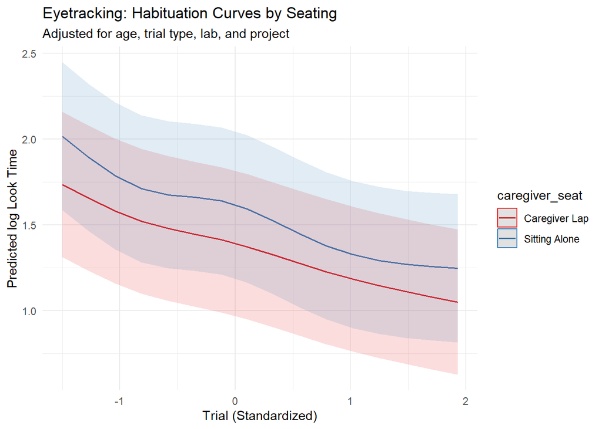

```r
# Habituation curves by seating
plot(ggpredict(eye_model, terms = c("trial_sc [all]", "caregiver_seat"))) +
  labs(title    = "Eyetracking: Habituation Curves by Seating",
       subtitle = "Adjusted for age, trial type, lab, and project",
       x        = "Trial (Standardized)",
       y        = "Predicted log Look Time") +
  theme_minimal()
```

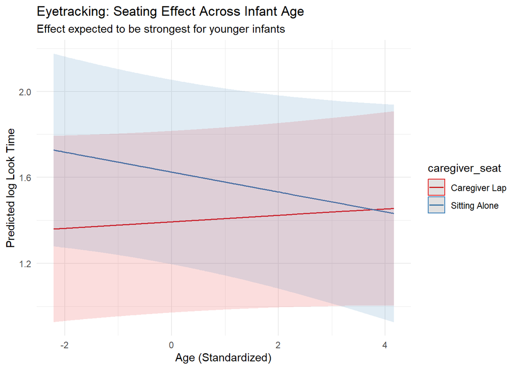

```r
# Seating × Age interaction within eyetracking
plot(ggpredict(eye_model, terms = c("age_sc [all]", "caregiver_seat"))) +
  labs(title    = "Eyetracking: Seating Effect Across Infant Age",
       subtitle = "Effect expected to be strongest for younger infants",
       x        = "Age (Standardized)",
       y        = "Predicted log Look Time") +
  theme_minimal()
```

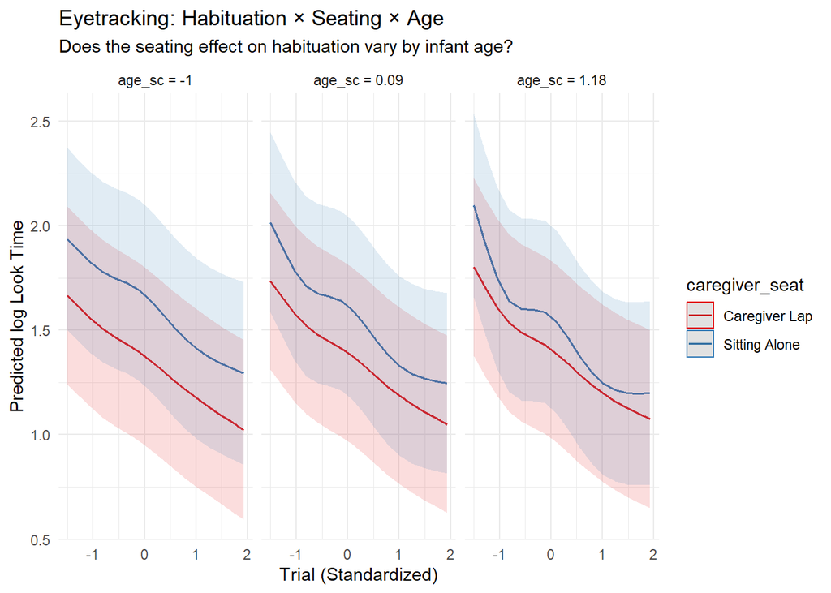

```r
# Full 3-way interaction plot
plot(ggpredict(eye_model, terms = c("trial_sc [all]", "caregiver_seat", "age_sc"))) +
  labs(title    = "Eyetracking: Habituation × Seating × Age",
       subtitle = "Does the seating effect on habituation vary by infant age?",
       x        = "Trial (Standardized)",
       y        = "Predicted log Look Time") +
  theme_minimal()
```

## 3.6 Conclusion

In our mixed-effects model analysis, the fixed-effects coefficient for caregiver_seatSitting Alone was positive and significant (b = 0.18, β = 0.26, SE = 0.046, p < .001). This indicates that infants sitting alone showed higher log looking times than those on the caregiver’s lap at the reference level of the model.

A noteworthy discovery in this exploratory analysis was the structural confounding between seating and lab identity. Diagnostic analysis revealed that 12.7% of the 126 participating labs (16 out of 126) utilized both “Caregiver Lap” and “Sitting Alone” protocols, while the remaining sites relied exclusively on a single seating arrangement. This confirms that seating is oftentimes a fixed methodological choice made at the lab level. As such, the differences reported here might reflect lab-to-lab differences in specialized equipment, such as specific eyetracker mounts, high-chairs, seats, or harnesses, as well as differing levels of researcher expertise in optimizing infant comfort and cooperation during the habituation procedure.

While our mixed-effects models account for lab-to-lab variability through random intercepts (where lab_id variance was 0.06), the high degree of structural imbalance across the dataset means we cannot entirely disentangle the physical impact of the seat from broader lab-specific characteristics. The reversal between the raw unadjusted data (where lap infants look longer) and the modeled estimates (where alone infants look longer) highlights the necessity of controlling for measurement method. Because “Sitting Alone” is heavily clustered in eyetracking (25.1% of trials) compared to HPP (1.7%), the “Sitting Alone” advantage only becomes visible once the systematic differences in data capture between eyetracking and human coding are resolved. Given these findings, researchers should consider seating arrangement as a methodological covariate in any analyses, particularly in eyetracking studies of infant attention. At the very least, we strongly encourage developmental researchers to consistently report the seating arrangements used for their samples to facilitate more accurate cross-study comparisons.